[figure not shown]

# Optimisation and Simulation of X-ray images: Automatic registration of surface models on synchrotron microtomography data

## Franck P. Vidal, Iwan T. Mitchell, and Jean Michel Létang

[figure not shown]

# Acknowledgements

- **Jean-Yves Buffière** and **Ce Xiao** of MATEIS laboratory (Lyon), and **Wolfgang Ludwig** of ESRF (Grenoble) for the new projection and CT data,
- **NVIDIA Corporation** for the donation of the NVIDIA TITAN Xp GPU used in the development and validation of gVirtualXRay,
- **Supercomputing Wales** for the use of its supercomputer, and
- **All the volunteers** who participated to the user study.

# Motivations

- The presence of **strong imaging artefacts** in **microtomographic X-ray** data makes the **CAD modelling process difficult** to carry out.
- A **user study** was conducted to **manually extract geometrical properties** from the CT slice.
- As an alternative to **manual measurements** and **traditional image segmentation techniques**, we proposed to **register CAD models** by deploying a realistic **X-ray simulation on GPU** in an **optimisation** framework.

# Scanned object

| Photograph | Optical microscopy |
| --- | --- |

- Matrix: mixture composed of titanium (90%), aluminium (6%) and vanadium (4%).
- Fibres: silicon carbide, and
- Cores: tungsten.

# Context: Artefacts in CT

- Data acquired at ESRF;
- multilayer monochromator used to make the beam spectrum **almost monochromatic**;
- Selected an energy of **33 keV**.

[figure not shown]

# Linear attenuation coefficients (μ) in cm<sup>-1</sup> from the literature (Theoretical), and from the CT slice of the experiment at ESRF (Experimental)

| Structure | Material | Theoretical | Experimental | Error |
| --- | --- | --- | --- | --- |
| Core | W | 341.61 | 162.34±21.67 | −179.27 |
| Fibre | SiC | 2.74 | 5.61±5.73 | +2.87 |
| Matrix | Ti90Al6V4 | 13.13 | 12.87±3.57 | −0.26 |

- **W** μ are **underestimated** by a factor of **2**;
- **SiC** coefficients are **overestimated** by a factor of **2**;
- **Ti90Al6V4** coefficients are right.

# Manual extraction of geometrical parameters

- Anonymous user-study;
- 13 participants measured
  - the size, position and orientation of the matrix, and
  - the size of the fibres,
  - the size of the cores.
- Maybe some of you responded ;-)

# Ti90Al6V4 Matrix

| What | Min | Median | Max | Average$\pm$stddev | [Max - Min] |
| --- | --- | --- | --- | --- | --- |
| Width (μm) | 1478 | 1499 | 5149 | 1789$\pm$1011 | 3671 |
| Height (μm) | 1056 | 1068 | 1501 | 1113$\pm$123 | 445 |
| Rotation (degrees) | 55 | 91 | 95 | 88.5$\pm$10.1 | 40 |
| Centre x-axis (μm) | 988 | 999 | 1742 | 1057$\pm$206 | 754 |
| Centre y-axis (μm) | 238 | 921 | 963 | 870$\pm$191 | 726 |

- **One outlier** (which is why the median value may be more relevant than the average);
- **Variability** amongst participants (cf stddev and [Max - Min]);
- *What is the truth?*

# Fibres and cores

| What | Min | Median | Max | Average$\pm$stddev | [Max - Min] |
| --- | --- | --- | --- | --- | --- |
| W core diameter (μm) | 16.0 | 20.0 | 28.0 | 20.4$\pm$2.2 | 12.0 |
| SiC fibre diameter (μm) | 104.0 | 108.6 | 116.0 | 109.6$\pm$2.8 | 12.0 |

- No outlier; but
- **Still variability** amongst participants,
  - in particular for the **W core diameter**;
- *What is the truth?*

# Methodology: Image registration as an optimisation algorithm

[figure not shown]

1. CAD models of the scanned object are generated
2. A CT acquisition is simulated to create X-ray projections from the CAD models
3. Simulated X-ray projections are compared with the projections from the real experiments
4. An optimisation algorithm tweaks the parameters of the simulation models (CAD & CT acquisition) until convergence

# Requirements

- CT scan acquisition simulated in an objective function;
- Objective function repeated numerous times with different parameters;
- Trade off between speed and accuracy:
  - No Monte Carlo simulation;
  - Fast analytical simulation on GPU
  - From surface models.
- Open source software only (image processing, optimisation algorithm, X-ray simulation)
- Prototype in Python

[figure not shown]

# 1. CAD models of the scanned object are generated

- A hollowed parallelepiped (matrix)
- Hollowed cylinders (fibres)
- Cylinders (cores)

[figure not shown]

# 2. A CT acquisition is simulated to create X-ray projections from the CAD models

[figure not shown]

- Number of angles, angular span
- Geometric properties of the CT acquisition:

[figure not shown]

**Raw projection** modelled using the polychromatic version of the Beer-Lambert law: $$\mathbf{I}(x,y) = \sum_i \mathbf{R}_i \, \mathbf{N}_i \; \exp\left({-\sum_j \mu_j(E_i) \; \mathbf{d}_j(x,y)}\right)$$

- $\mathbf{I}(x,y)$ the value of the raw X-ray projection at pixel location $(x,y)$;
- $i$ the $i$-th energy channel in the beam spectrum;
- $E_i$ the energy in eV;
- $\mathbf{R}_i$ and $\mathbf{N}_i$ the detector response and the number of photons at that energy;
- $j$ the $j$-th material being scanned, $\mu_j(E_i)$ its linear attenuation coefficient at energy $E_i$, and
- $\mathbf{d}_j(x,y)$ path length in cm$^{-1}$ of the ray crossing the $j$-th material from the X-ray source to pixel $(x,y)$.

**Flat-field correction** is then applied on: $$\mathbf{Proj} = \frac{\mathbf{I} - \mathbf{D}}{\mathbf{F} - \mathbf{D}}$$ $\mathbf{F}$ (full fields) and $\mathbf{D}$ (dark fields) are projection images without sample and acquired with and without the X-ray beam turned on respectively.

**Linearisation of the transmission data** to get the sinogram: $$\textbf{Sino}=-\ln\left(\textbf{Proj}\right)$$

# Beer-Lambert law enhanced with

- Polychromatism
- Phase
- Impulse response of detector
- Poisson noise

# Summary of the parameters that need to be optimised

| # | Parameter |
| --- | --- |
| 1 | Position of the matrix along the primary axis (in μm) |
| 2 | Position of the matrix along the secondary axis (in μm) |
| 3 | Size of the matrix along the primary axis (in μm) |
| 4 | Size of the matrix along the secondary axis (in μm) |
| 5 | Rotation angle of the matrix (in degrees) |
| 6 | Radius of the cores (in μm) |
| 7 | Radius of the fibres (in μm) |
| 8 | Percentage of 33 keV photons in the beam spectrum |
| 9 | Percentage of 66 keV photons in the beam spectrum |
| 10 | Percentage of 99 keV photons in the beam spectrum |
| 11 | Bias controlling the Poisson noise |
| 12 | Gain controlling the Poisson noise |
| 13 | Intensity of the Poisson noise |
| 14 | Intensity of the phase contrast for the tungsten core |
| 15 | Spread of the phase contrast for the tungsten core |
| 16 | Intensity of the phase contrast for the SiC fibres |
| 17 | Spread of the phase contrast for the SiC fibres |
| 18 | Intensity of the phase contrast for the Ti90Al6V4 matrix |
| 19 | Spread of the phase contrast for the Ti90Al6V4 matrix |
| 20-23 | Parameters of the LSF |

# Registration pipeline: Divide and Conquer

- There are too many parameters to optimise everything in one go
- Breaks down the registration problem into sub-problems of the same type
- They become simple enough to be solved directly

[figure not shown]

# 3. Simulated X-ray images are compared with the images from the real experiments

Must choose the objective function carefully:

- which images to compare?
- do we pre-process them and how?
- how to compare them?

# Which images to compare?

[figure not shown]

| Candidate | image | Comment |
| --- | --- | --- |
| Projections ($\mathbf{Projs}$) after flat-field correction |  | Possible candidate |
| Sinogram, i.e. $\mathbf{Sino} = -\ln(\mathbf{Projs})$ |  | Possible candidate |
| Reconstructed CT slice |  | Discarded as it involves the CT reconstruction |

# Do we pre-process them and how?

**Do nothing**

- It should work in theory

**Min-max normalisation**

$$\mathbf{m}_o=\frac{\mathbf{m}-\min(\mathbf{m})}{\max(\mathbf{m}) - \min(\mathbf{m})}$$

- where $\mathbf{m}_o$ is the image after normalisation of Image $\mathbf{m}$
- after normalisation, $\min(\mathbf{m}_o)=0$ and $\max(\mathbf{m}_o)=1$
- discarded as too sensitive to Poisson noise

**Zero-mean, unit-variance normalisation** (also known as standardisation or Z-score normalisation in machine learning)

$$\mathbf{m}_o=\frac{\mathbf{m}-\overline{m}}{\sigma_m}$$

- where $\overline{m}$ is the average pixel value of Image $\mathbf{m}$, and $\sigma_m$ its standard deviation.
- after normalisation, $\overline{m_o} = 0$ and $\sigma_{m_o} = 1$
- why not? It's popular in computer vision and machine learning after all

# Which image comparison method?

[figure not shown]

- MAE (super fast, robust to outliers),
- RMSE (quite fast, give a higher weight to large discrepencies (outliers) than MAE),
- SSIM (popular in computer vision),
- ZNCC (popular in computer vision).

# Exaustive evaluation on a Supercomputer

- 14 objective functions in total: every possible combination (image, image metrics, with/without normalisation).
- Run the registration on each objective functions 25 times to gather statistically meaninful data.
- 350 registrations in total (23 days).
- A registration is 1 hour 35 minute (average)
- Best objective: RMSE on **Sino** with zero-mean, unit-variance normalisation

[figure not shown]

# Comparison of the 3 best strategies

- Select the objective functions that works best (in terms of accuracy) on the supercomputer
- Perfrom another $3 \times 25$ registrations on a desktop PC
  - i.e. 25 per objective function
  - compare the performance between supercomputer and my office PC

[figure not shown]

# 4. An optimisation algorithm tweaks the parameters of the simulation models (CAD & CT acquisition) until convergence

[figure not shown]

- Use one of today's most popular global optimisation algorithm: covariance matrix adaptation evolution strategy (CMA-ES);
- Evolutionary algorithm designed for difficult non-linear non-convex optimisation problems in continuous domain;
- Considered as state-of-the-art in evolutionary computation;
- Does not require a tedious parameter tuning:
  - finding suitable internal parameters is part of the algorithm design;
- Only an initial solution and an initial standard deviation must be set by the user.
- The default population size is relatively small for fast convergence.

## Simulate the CT acquisition

There are 7 successive steps to simulate the XCT data acquisition:

1. Set the cores and fibre geometries and material properties
2. Set the matrix geometry and material properties
3. Simulate the raw projections for each angle:
   - Without phase contrast, or
   - With phase contrast
4. Apply the LSF
5. Apply the flat-field correction
6. Add Poison noise
7. Apply the minus log linearisation to compute the sinogram

# Register the Ti90Al6V4 matrix geometry

[figure not shown]

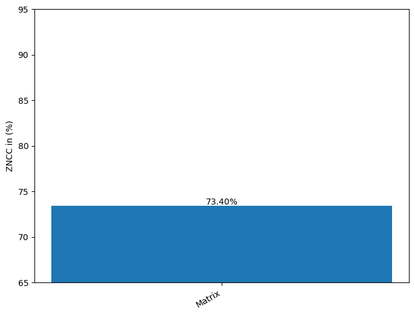

```python
plotSetOfZNCC(ZNCC_set, ZNCC_label_set)
```

# Find the centre of fibres

[figure not shown]

# Find circles to identify the centre of fibres

We can use the Hoguh transform to detect where circles are in the image. However, the input image in OpenCV's function must be in UINT. We blur it using a bilateral filter (an edge-preserving smoothing filter).

[figure not shown]

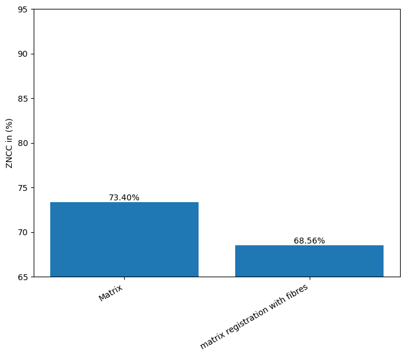

```python
plotSetOfZNCC(ZNCC_set, ZNCC_label_set)
```

# Optmise core and fibre radii

[figure not shown]

```python
print("Core diameter:", round(core_radius * 2), "um");
print("Fibre diameter:", round(fibre_radius * 2), "um");
```

```
Core diameter: 16 um
Fibre diameter: 101 um
```

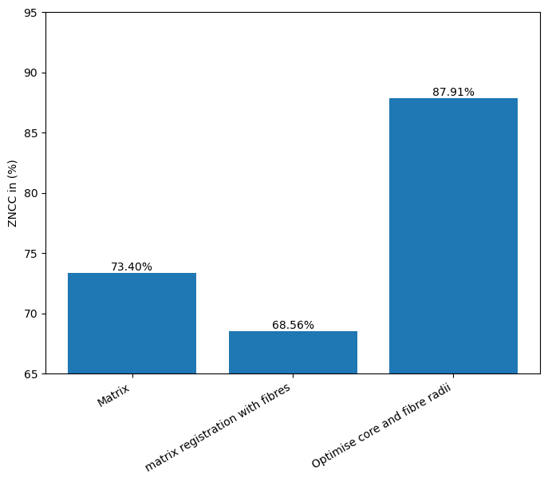

```python
plotSetOfZNCC(ZNCC_set, ZNCC_label_set)
```

# Recentre the cores and fibres

[figure not shown]

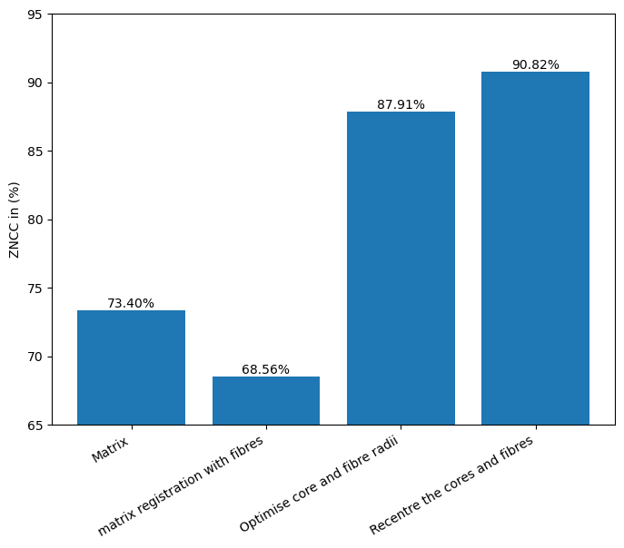

```python
plotSetOfZNCC(ZNCC_set, ZNCC_label_set)
```

# Reoptmise core and fibre radii

[figure not shown]

```python
print("Core diameter:", round(core_radius * 2), "um");
print("Fibre diameter:", round(fibre_radius * 2), "um");
```

```
Core diameter: 16 um
Fibre diameter: 99 um
```

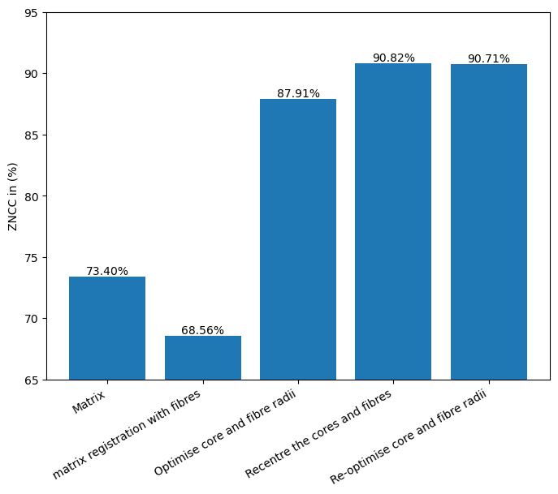

```python
plotSetOfZNCC(ZNCC_set, ZNCC_label_set)
```

# Optmise beam spectrum

[figure not shown]

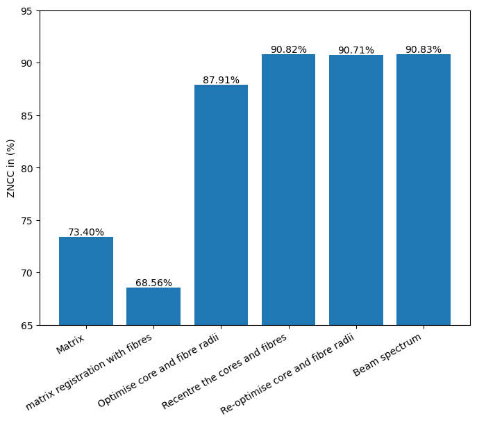

```python
plotSetOfZNCC(ZNCC_set, ZNCC_label_set)
```

# Optimisation of the phase contrast and the radii

[figure not shown]

```python
print("Core diameter:", round(core_radius * 2), "um");
print("Fibre diameter:", round(fibre_radius * 2), "um");
```

```
Core diameter: 16 um
Fibre diameter: 107 um
```

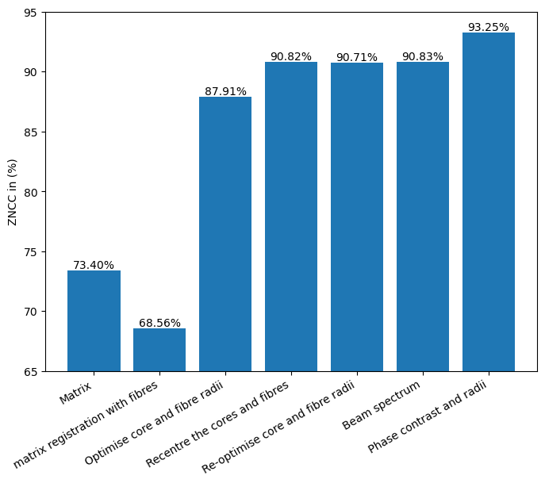

```python
plotSetOfZNCC(ZNCC_set, ZNCC_label_set)
```

# Optimisation of the phase contrast and the LSF

[figure not shown]

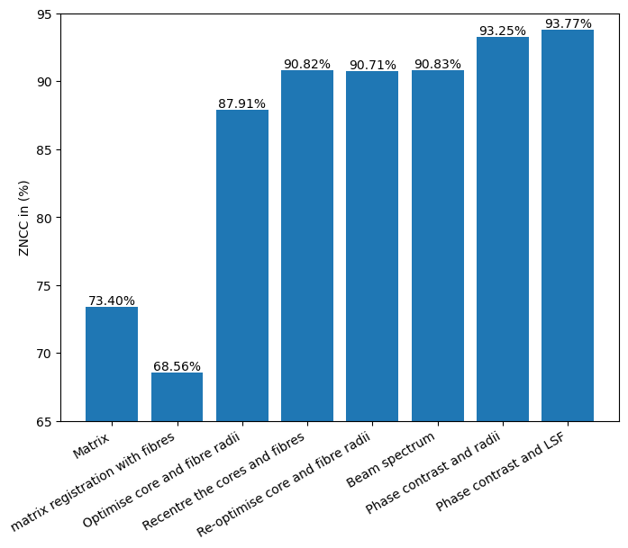

```python
plotSetOfZNCC(ZNCC_set, ZNCC_label_set)
```

[figure not shown]

# Recentre again

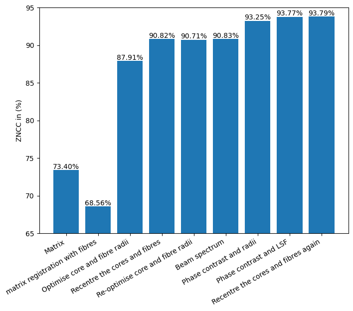

```python
plotSetOfZNCC(ZNCC_set, ZNCC_label_set)
```

## Extract the fibre in the centre of the CT slices

[figure not shown]

# Optimisation of the Poisson noise

[figure not shown]

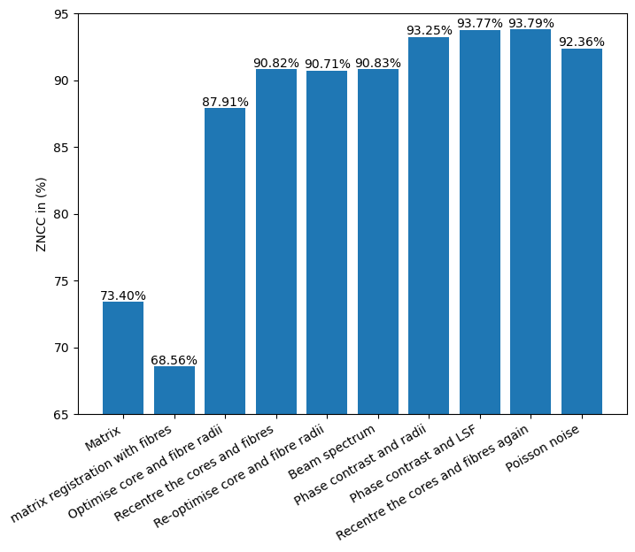

```python
plotSetOfZNCC(ZNCC_set, ZNCC_label_set)
```

# Manual measurement vs automatic

## Matrix

[output not shown]

**Similar results**, once the outliers were discarded.

## Fibres and Cores

[output not shown]

# Improving μ: Subtracting the contribution of each artefact sources

[figure not shown]

# Phase contribution to artefacts

[figure not shown]

# LSF contribution to artefacts

[figure not shown]

# Beam hardening contribution to artefacts

[figure not shown]

# Correction map

[figure not shown]

# Corrected CT slice

[figure not shown]

# Profile through the fibre in the centre of the slice

[figure not shown]

# Results in terms of linear attenuation coefficients

```python
display(df)
```

|  | CT | Structure | Composition | mean | error |
| --- | --- | --- | --- | --- | --- |
| 0 | Theorical | Core | W | 341.610000 | N/A |
| 1 | Experimental (corrected) |  |  | 295.885223 | 45.724777 |
| 2 | Experimental |  |  | 193.974380 | 147.63562 |
| 3 | Simulation |  |  | 175.826019 | 165.783981 |
| 4 | Theorical | Fibre | SiC | 2.736000 | N/A |
| 5 | Experimental (corrected) |  |  | 1.274483 | 1.461517 |
| 6 | Experimental |  |  | 3.189285 | -0.453285 |
| 7 | Simulation |  |  | 2.285063 | 0.450937 |
| 8 | Theorical | Matrix | Ti90Al6V4 | 13.127400 | N/A |
| 9 | Experimental (corrected) |  |  | 15.013135 | -1.885735 |
| 10 | Experimental |  |  | 10.639873 | 2.487527 |
| 11 | Simulation |  |  | 9.695848 | 3.431552 |

# Conclusion

- Manual measurements:
  - may seem to be relatively easy to perform
  - can be prone to bias and unreliable.
- **Realistic projection model required** to automatically produce an accurate CAD models from X-ray tomography **when CT data is so corrupted by artefacts**.
- Our model takes into account geometrical properties, beam hardening, impulse response of the detector, phase contrast, and photon noise.
- The **choice of the objective function** for the optimisation is very important.
- Our method is only suitable when it is possible to generate surface models.
  - Not trivial to model complex shapes.
- All the geometrical properties, e.g. tilting and warping the shapes, must be implemented if needed.
- Taking into account features such as **pores** or **fibre tows**, even if made of basic shapes, is not straightforward.

# Future work

- Deformable models to generate complex shapes.
- Model-based iterative reconstruction:
  - Improve qualitative data (remove the artefacts in the image),
  - Improve quantitative data (improve the μ values).
- (if you have a CT scan with simple geometries, we'll be happy to collaborate and test the framework with your data)

# Thanks for your attention

(contact details: f.vidal@bangor.ac.uk)